# hw1 - html

#### Homework Setup

```python
# Importing relevant packages
import pandas as pd
import seaborn as sns
import matplotlib.pyplot as plt
import numpy as np
import scipy.stats
from sklearn.model_selection import train_test_split
from sklearn.linear_model import LinearRegression
from sklearn.ensemble import RandomForestRegressor
from sklearn.preprocessing import LabelEncoder
from sklearn.metrics import mean_squared_error, r2_score
```

```python
# Reading the dataset
!curl -L -O https://github.com/mosesyhc/de300-2026sp/raw/refs/heads/main/homework/T_F41SCHEDULE_B43_with_missing.zip
inventory = pd.read_csv('T_F41SCHEDULE_B43_with_missing.zip')
```

```
  % Total    % Received % Xferd  Average Speed   Time    Time     Time  Current
                                 Dload  Upload   Total   Spent    Left  Speed

  0     0    0     0    0     0      0      0 --:--:-- --:--:-- --:--:--     0
  0     0    0     0    0     0      0      0 --:--:-- --:--:-- --:--:--     0
  0     0    0     0    0     0      0      0 --:--:-- --:--:-- --:--:--     0

100 1577k  100 1577k    0     0  1745k      0 --:--:-- --:--:-- --:--:-- 1745k
```

```python
inventory.head()
rows_before = len(inventory)
```

#### Task 1

```python
# Calulating summary statistics for the relevant columns
investigation_cols = ["CARRIER", "CARRIER_NAME", "MANUFACTURE_YEAR", "NUMBER_OF_SEATS", "CAPACITY_IN_POUNDS", "AIRLINE_ID"]
missing_values = inventory[investigation_cols].isnull().sum()
percentage_missing = (missing_values / len(inventory))*100
missing_data_summary = pd.DataFrame({
    'Data Types': inventory[investigation_cols].dtypes,
    'Missing Values': missing_values,
    'Percentage Missing': percentage_missing,
    'Unique Values': inventory[investigation_cols].nunique()
})
missing_data_summary
```

|  | Data Types | Missing Values | Percentage Missing | Unique Values |
| --- | --- | --- | --- | --- |
| CARRIER | object | 49 | 0.037033 | 177 |
| CARRIER_NAME | object | 105 | 0.079357 | 133 |
| MANUFACTURE_YEAR | float64 | 3 | 0.002267 | 76 |
| NUMBER_OF_SEATS | float64 | 13238 | 10.005064 | 148 |
| CAPACITY_IN_POUNDS | float64 | 13332 | 10.076107 | 2205 |
| AIRLINE_ID | float64 | 105 | 0.079357 | 112 |

Now that we have some basic understanding about the data and what it looks like, we can analyse the data in each of the columns to determine whether imputation is psossible in each case.

```python
# Starting to investigate the missing values in the "CARRIER" column
missing_carier = inventory[inventory['CARRIER'].isnull()]
print(missing_carier[["CARRIER", "CARRIER_NAME", "AIRLINE_ID"]].drop_duplicates())
# Here, we observed that all the 49 rows of missing carriers corresponded to the same airline, North American Airlines which had the airline ID of
# 20415. Now, we can use this airline ID to determine the carrier code for North American Airlines and fill in the missing values in the "CARRIER" column accordingly.

print(inventory[inventory['AIRLINE_ID'] == 20415][['YEAR', 'CARRIER', 'CARRIER_NAME']].drop_duplicates())
# From this, we know that the appropriate carrier code for North American Airlines is "NA". This can be used to fill in missing values in this column with "NA" replacing the null values.
# Hence, imputation is possible for this column and can be done through the function below.
```

```
      CARRIER             CARRIER_NAME  AIRLINE_ID
11776     NaN  North American Airlines     20415.0
       YEAR CARRIER             CARRIER_NAME
11776  2007     NaN  North American Airlines
19009  2008     NaN  North American Airlines
26207  2009     NA   North American Airlines
33678  2010     NaN  North American Airlines
40715  2011     NaN  North American Airlines
47729  2012     NaN  North American Airlines
54546  2013     NaN  North American Airlines
```

```python
# Imputation function for for the "Carrier" column
def impute_carrier(df):
    df = df.copy()
    mask = df['CARRIER'].isnull() & (df['AIRLINE_ID'] == 20415)
    df.loc[mask,'CARRIER'] = 'NA'
    return df

# Applying this imputation:
inventory = impute_carrier(inventory)
```

We observe that "CARRIER_NAME" and "AIRLINE_ID" both have 105 missing values each. This means that if thse missing values are the same for both columns, we can analyse how to impute the values for both these columns at the same time.

```python
# Checking to see if the missing values are the same for both columns:
missing_carrier_name = set(inventory[inventory['CARRIER_NAME'].isnull()].index)
missing_airline_id = set(inventory[inventory['AIRLINE_ID'].isnull()].index)
print(missing_carrier_name == missing_airline_id)

# Given that the missing values for the columns are the same, we can check which are the carrier codes appear in the missing rows.
print(inventory[inventory['CARRIER_NAME'].isnull()][['CARRIER', 'YEAR']].value_counts())
```

```
True
CARRIER  YEAR
OH       2013    97
L4       2007     8
Name: count, dtype: int64
```

```python
# For the carrier L4, we can look up non-null rows that use the same 'carrier' to determine carrier name and airline ID for thse airlines
known_L4 = inventory[(inventory['CARRIER'] == 'L4') & inventory['CARRIER_NAME'].notnull()]
print(known_L4[['CARRIER', 'CARRIER_NAME', 'AIRLINE_ID']].drop_duplicates())
# Thus, L4 corresponds to the Carrier_Name Lynx Aviation d/b/a Frontier Airlines with an airline ID of 21217.

# Applying the same method for the carrier code OH:
known_OH = inventory[(inventory['CARRIER'] == 'OH') & inventory['CARRIER_NAME'].notnull()]
print(known_OH.groupby(['CARRIER_NAME', 'AIRLINE_ID']).agg(year_min=('YEAR', 'min'), year_max=('YEAR', 'max')).reset_index())
```

```
      CARRIER                           CARRIER_NAME  AIRLINE_ID
18739      L4  Lynx Aviation d/b/a Frontier Airlines     21217.0
        CARRIER_NAME  AIRLINE_ID  year_min  year_max
0        Comair Inc.     20417.0      2006      2011
1  PSA Airlines Inc.     20397.0      2015      2023
```

Here, we observe that OH as a carrier was used by two different airlines - Comair and PSA across different timespans. However, the period of missing data occurs in 2013 only, which indicates that we need another feature from the dataset to help us impute the specific airline assignments. The tail number can be used as this tiebreaker.

```python
# Determining tail numbers for Comair and PSA, and then comparing them to the tail numbers for the 2013 flights to check overlap:
OH_tail_nos = set(inventory[(inventory['CARRIER'] == 'OH')  & (inventory['YEAR'] == 2013)]['TAIL_NUMBER'])
comair_tail_nos = set(inventory[inventory['AIRLINE_ID'] == 20417.0]['TAIL_NUMBER'])
psa_tail_nos = set(inventory[inventory['AIRLINE_ID'] == 20397.0]['TAIL_NUMBER'])

print(len(OH_tail_nos & comair_tail_nos))
print(len(OH_tail_nos & psa_tail_nos))
```

```
97
0
```

Here, we identify that all 97 of the OH carriers have overlapping tail numbers with Comair Inc. aircrafts. Thus, we can assign these 97 directly to Comair. Thus, we can draw up an imputation function to handle both the L4 and OH cases for both carrier name and airline ID.

```python
def impute_carrier_name_airline_id(df):
    df = df.copy()
    mask_l4 = (df['CARRIER'] == 'L4') & df['CARRIER_NAME'].isnull()
    df.loc[mask_l4, 'CARRIER_NAME'] = 'Lynx Aviation d/b/a Frontier Airlines'
    df.loc[mask_l4, 'AIRLINE_ID'] = 21217.0

    mask_oh = (df['CARRIER'] == 'OH') & df['CARRIER_NAME'].isnull()
    df.loc[mask_oh, 'CARRIER_NAME'] = 'Comair Inc.'
    df.loc[mask_oh, 'AIRLINE_ID'] = 20417.0

    return df

# Applying this imputation function:
inventory = impute_carrier_name_airline_id(inventory)
```

The next column we can address is the MANUFACTURE_YEAR of the aircrafts. There are three missing values that we can look more into.

```python
print(inventory[inventory['MANUFACTURE_YEAR'].isnull()][['CARRIER', 'CARRIER_NAME', 'TAIL_NUMBER', 'AIRLINE_ID']])
```

```
       CARRIER       CARRIER_NAME TAIL_NUMBER  AIRLINE_ID
116651      5Y     Atlas Air Inc.      N664GT     20007.0
124680      9E  Endeavor Air Inc.      N655CA     20363.0
124681      9E  Endeavor Air Inc.      N690CA     20363.0
```

In order to determine the manufacture year for these rows, we can search for their tail number in other rows as it is a unique idenitfier for the aircraft. This can help us find the manufacture year if the same tail number is present in the dataset.

```python
for i in ['N664GT', 'N655CA', 'N690CA']:
    known = inventory[(inventory['TAIL_NUMBER'] == i) & inventory['MANUFACTURE_YEAR'].notnull()]['MANUFACTURE_YEAR'].unique()
    print(f'{i}: {known}')
```

```
N664GT: []
N655CA: [2004.]
N690CA: [2004.]
```

Thus, we observe that for the bottom two carriers, we known the manufacturing year is 2004 so we can impute that into the data. For the first, there are no other corresponding rows in the dataset with that tail number, so there is no possibility of imputation for that value. Proceeding with the imputation:

```python
def impute_manufacture_year(df):
    df = df.copy()
    df.loc[df['TAIL_NUMBER'] == 'N655CA', 'MANUFACTURE_YEAR'] = 2004.0
    df.loc[df['TAIL_NUMBER'] == 'N690CA', 'MANUFACTURE_YEAR'] = 2004.0
    return df

impute_manufacture_year(inventory)
```

|  | YEAR | CARRIER | CARRIER_NAME | MANUFACTURE_YEAR | UNIQUE_CARRIER_NAME | SERIAL_NUMBER | TAIL_NUMBER | AIRCRAFT_STATUS | OPERATING_STATUS | NUMBER_OF_SEATS | MANUFACTURER | AIRCRAFT_TYPE | MODEL | CAPACITY_IN_POUNDS | ACQUISITION_DATE | AIRLINE_ID | UNIQUE_CARRIER |
| --- | --- | --- | --- | --- | --- | --- | --- | --- | --- | --- | --- | --- | --- | --- | --- | --- | --- |
| 0 | 2006 | 16 | PSA Airlines Inc. | 2003.0 | PSA Airlines Inc. | 7858 | N202PS | B | Y | 50.0 | CANADAIR | NaN | CRJ-2/4 | 47000.0 | 10/28/2003 12:00:00 AM | 20397.0 | 16 |
| 1 | 2006 | 16 | PSA Airlines Inc. | 2003.0 | PSA Airlines Inc. | 7860 | N206PS | B | Y | 50.0 | CANADAIR | NaN | CRJ-2/4 | 47000.0 | 10/30/2003 12:00:00 AM | 20397.0 | 16 |
| 2 | 2006 | 16 | PSA Airlines Inc. | 2003.0 | PSA Airlines Inc. | 7873 | N207PS | B | Y | 50.0 | CANADAIR | NaN | CRJ-2/4 | 47000.0 | 11/26/2003 12:00:00 AM | 20397.0 | 16 |
| 3 | 2006 | 16 | PSA Airlines Inc. | 2003.0 | PSA Airlines Inc. | 7874 | N209PS | B | Y | 50.0 | CANADAIR | NaN | CRJ-2/4 | 47000.0 | 12/4/2003 12:00:00 AM | 20397.0 | 16 |
| 4 | 2006 | 16 | PSA Airlines Inc. | 2003.0 | PSA Airlines Inc. | 7879 | N213PS | B | Y | 50.0 | CANADAIR | NaN | CRJ-2/4 | 47000.0 | 12/16/2003 12:00:00 AM | 20397.0 | 16 |
| ... | ... | ... | ... | ... | ... | ... | ... | ... | ... | ... | ... | ... | ... | ... | ... | ... | ... |
| 132308 | 2023 | ZW | Air Wisconsin Airlines Corp | 2004.0 | Air Wisconsin Airlines Corp | 7899 | N466AW | O | Y | 50.0 | Bombardier | 6291 | CL-600-2B19 | NaN | 1/21/2004 12:00:00 AM | 20046.0 | ZW |
| 132309 | 2023 | ZW | Air Wisconsin Airlines Corp | 2004.0 | Air Wisconsin Airlines Corp | 7900 | N467AW | O | Y | 50.0 | Bombardier | 6291 | CL-600-2B19 | NaN | 1/23/2004 12:00:00 AM | 20046.0 | ZW |
| 132310 | 2023 | ZW | Air Wisconsin Airlines Corp | 2004.0 | Air Wisconsin Airlines Corp | 7916 | N468AW | O | Y | 50.0 | Bombardier | 6291 | CL-600-2B19 | NaN | 3/25/2004 12:00:00 AM | 20046.0 | ZW |
| 132311 | 2023 | ZW | Air Wisconsin Airlines Corp | 2004.0 | Air Wisconsin Airlines Corp | 7917 | N469AW | O | Y | 50.0 | Bombardier | 6291 | CL-600-2B19 | NaN | 3/18/2004 12:00:00 AM | 20046.0 | ZW |
| 132312 | 2023 | ZW | Air Wisconsin Airlines Corp | 2004.0 | Air Wisconsin Airlines Corp | 7927 | N470ZW | O | Y | 50.0 | Bombardier | 6291 | CL-600-2B19 | NaN | 5/3/2004 12:00:00 AM | 20046.0 | ZW |

132313 rows × 17 columns

The next columns to address are the "NUMBER_OF_SEATS" and "CAPACITY_IN_POUNDS". These columns both have a similar number of missing values, so they could potentially be imputed in conjuction. First, its important to understand the nature of the missing data by establishing the mechanism for missingness. This can be done by addressing whether the rows missing seats are cargo planes (which would have none) or passenger aircrafts that have seats but the data hasn't been filled in.

```python
missing_seats = inventory[inventory['NUMBER_OF_SEATS'].isnull() & inventory['MODEL'].str.contains('PAX|PASSENGER|PSGR', case = False, na = False)]
print(missing_seats['CARRIER_NAME'].value_counts())
```

```
CARRIER_NAME
Delta Air Lines Inc.                           3164
United Air Lines Inc.                          2250
American Airlines Inc.                          576
Spirit Air Lines                                209
Continental Air Lines Inc.                      114
Omni Air International LLC                       65
AirTran Airways Corporation                      38
Eastern Airlines f/k/a Dynamic Airways, LLC      37
Omni Air Express                                 27
North American Airlines                          19
Dynamic Airways, LLC                             19
World Airways Inc.                               12
Vision Airlines                                   5
Name: count, dtype: int64
```

Here, we observe ~6500 rows from major carriers like Delta, United and American Airlines on aircraft models explicitly meant for passenger travel. These carriers have data that appears with seat counts known for the same aircraft models in other years. This means the value is not a structural absence, so the data cannot be MNAR. To determine if the data is MAR, we can check whether the missingness can be predicted by another known value in the dataset, potentially the model of the aircraft.

```python
model_counting = inventory.dropna(subset = ['NUMBER_OF_SEATS']).groupby('MODEL')['NUMBER_OF_SEATS'].nunique()
print(f'Model with 1 (exact) unique seat count:{(model_counting ==1).sum()}')
print(f'Model with >1 unique seat count:{(model_counting >1).sum()}')
# Checking the same thing for CAPACITY_IN_POUNDS:
model_counting_capacity = inventory.dropna(subset = ['CAPACITY_IN_POUNDS']).groupby('MODEL')['CAPACITY_IN_POUNDS'].nunique()
print(f'Model with 1 (exact) unique capacity in pounds count:{(model_counting_capacity ==1).sum()}')
```

```
Model with 1 (exact) unique seat count:857
Model with >1 unique seat count:335
Model with 1 (exact) unique capacity in pounds count:638
```

These insights highlight that the model of the aircraft is fully observed and has strong predictive power over the missing value for a majority of seat count and capacity cases. Thus, this provides strong support that the data is missing at random (MAR). This eliminates both mean and median imputation as they fail to account for the observed relationship between model and the target variables. This leads to predictive mean matching (PMM) becoming advantageous as it leverages these exact relationships (KNN was preferred but it required significant computation time).

```python
import miceforest as mf

def impute_seats_capacity_pmm(df, num_datasets = 1, num_iterations = 5, mean_match_candidates = 5, random_state = 42):
    df = df.copy()
    df['MODEL_CODE'] = df['MODEL'].astype('category').cat.codes
    # Ensuring a numeric matrix for mice forest
    numeric_columns_in_set = ['MANUFACTURE_YEAR', 'MODEL_CODE', 'NUMBER_OF_SEATS', 'CAPACITY_IN_POUNDS']

    kernel_pmm = mf.ImputationKernel(
        data = df[numeric_columns_in_set],
        num_datasets = num_datasets,
        mean_match_candidates = mean_match_candidates,
        random_state = random_state,
        save_all_iterations_data = False
    )
    kernel_pmm.mice(num_iterations)
    post_imputation = kernel_pmm.complete_data(dataset = 0)
    df['NUMBER_OF_SEATS'] = post_imputation['NUMBER_OF_SEATS']
    df['CAPACITY_IN_POUNDS'] = post_imputation['CAPACITY_IN_POUNDS']
    df.drop(columns = 'MODEL_CODE', inplace = True)
    return df

inventory = impute_seats_capacity_pmm(inventory)
```

#### Task 2

Starting with the 'MANUFACTURER' column:

```python
print(inventory['MANUFACTURER'].value_counts())
print(f'Unique Values: {inventory["MANUFACTURER"].nunique()}')
```

```
MANUFACTURER
BOEING                                                                              15922
Embraer                                                                             11508
THEBOEINGCO                                                                          9223
Bombardier                                                                           8871
Boeing                                                                               8392
                                                                                    ...
BEECHCRAFT                                                                              1
FOKKER71                                                                                1
FOKKER70                                                                                1
FOKKER72                                                                                1
MCDONNEL                                                                                1
Name: count, Length: 183, dtype: int64
Unique Values: 183
```

From here, we observe that the same manufacturer appears under many different name. For instance, 'Boeing' appears as 'BOEING', 'THEBOEINGCO' and 'Boeing' from a small snippet of the output. There are 183 unique values in this section that need standardization. We can first try case standardization and also remove all punctuation and spaces to determine all types of variants and reduce the unique count. This is followed up by using a pattern-matching column to determine which manufacturer the stripped key corresponds to.

```python
def standardize_manufactuer(df):
    df = df.copy()
    df['MANUFACTURER'] = df['MANUFACTURER'].str.upper()
    df['MANUFACTURER'] = df['MANUFACTURER'].str.strip()
    df['MATCHING_KEY'] = df['MANUFACTURER'].str.replace(r'[\s\.\-\(\)/]', '', regex = True)

    # Now, the matching key will be used to map the rows to the actual name of the manufacturer through a simple string lookup.
    dict_manufacturer = {
        'BOEING': 'BOEING',
        'AIRBUS': 'AIRBUS',
        'MCDONNELL|MCDO': 'MCDONNELL DOUGLAS',
        'BOMBARDIER': 'BOMBARDIER',
        'EMBRAER': 'EMBRAER',
        'CANADAIR': 'CANADAIR',
        'CESSNA': 'CESSNA',
        'DOUGLAS': 'DOUGLAS',
        'DEHAV': 'DE HAVILLAND',
        'SAAB': 'SAAB',
        'GULFSTREAM': 'GULFSTREAM',
        'LOCKHEED': 'LOCKHEED',
        'DASSAULT': 'DASSAULT',
        'DORNIER': 'DORNIER',
        'ATR': 'ATR',
        'FOKKER': 'FOKKER',
        'RAYTHEON|RAETHEON': 'RAYTHEON',
        'BAE': 'BAE',
        'PIPER|PIPISTREL': 'PIPER',
        'CURTISS': 'CURTISS',
        'GE': 'GENERAL ELECTRIC',
    }

    set_conditions = [df['MATCHING_KEY'].str.contains(i, na = False) for i in dict_manufacturer.keys()]
    options = list(dict_manufacturer.values())
    df['MANUFACTURER'] = np.select(set_conditions, options, default = df['MANUFACTURER'])
    df.drop(columns = 'MATCHING_KEY', inplace = True)
    return df

inventory = standardize_manufactuer(inventory)
```

```python
# Quickly verifying results:
print(inventory['MANUFACTURER'].value_counts())
print(f'Unique Values: {inventory["MANUFACTURER"].nunique()}')
```

```
MANUFACTURER
BOEING               55639
AIRBUS               23517
EMBRAER              15554
BOMBARDIER           12483
MCDONNELL DOUGLAS     9353
                     ...
CSSNACITATIONX           1
BEECHHAWKER400XP         1
AMA/EXPR                 1
B757-223                 1
JSA/PEACH                1
Name: count, Length: 86, dtype: int64
Unique Values: 86
```

Thus, we have reduced the number of unique values to 86. The remaining values (low percentage) are left as is because entry in different formats makes it hard to recognize specific manufacturer names. Now, we can move to the 'MODEL' column.

```python
print(inventory['MODEL'].value_counts().head(50))
print(f'Unique Values: {inventory["MODEL"].nunique()}')
```

```
MODEL
EMB-145                 2614
B-737-7H4               2470
B737-823                2370
A320-232                2333
A321-231                2259
737-700PASSENGERONLY    2027
C-208B                  1872
B757-2                  1775
CRJ-2/4                 1761
B737-800PAX             1621
MD-80                   1610
ERJ-170-200LR           1379
757-200                 1345
CRJ200-2B19             1342
A319                    1267
B-737-8H4               1256
CRJ-200                 1148
ERJ-175                 1132
SUPER80PASSENGER        1108
A320-1/2                1107
757-24APF               1039
B737-3                  1036
MD-88-PSGR              1028
C-208B/3                1017
MD-11                    991
757-232-PSGR             988
CRJ-900LR-PSGR           976
B737-823PASSENGER        956
B737-8                   951
B737-7/L                 929
CRJ-700                  880
737-832-PSGR             877
CRJ-200-PSGR             861
A319-112                 856
B737-900ERPAX            836
A320                     830
717-200-PSGR             785
B737-890ALLPAX           783
767-34AF                 783
EMB-140                  782
CRJ200                   781
CE-208B                  758
CRJ-900-PSGR             745
E190-100                 735
CRJ700-2C10              733
A300F4-622R              731
ERJ-145LR                721
A-320-PSGR               710
737-300PASSENGERONLY     708
0                        706
Name: count, dtype: int64
Unique Values: 1340
```

There are instantly three problems that can be addressed. The first is inconsistency in spacing, second is missing prefixes of B/A corresponding to Boeing or Airbus and the third is the presence of 706 values of '0' which can be discarded. All the Boeing models are 737, 747, 757, 767 and 777 - some of these have the B prefix missing while the same can be observed for the Airbus series of 319, 320 and 321 with its A prefix. We can check if this is a substantial enough problem to fix.

```python
print(inventory[inventory['MODEL'].str.match(r'^7[34567][0-9]', na = False)]['MODEL'].value_counts())
print(inventory[inventory['MODEL'].str.match(r'^3[012][0-9]', na = False)]['MODEL'].value_counts())
```

```
MODEL
737-700PASSENGERONLY    2027
757-200                 1345
757-24APF               1039
757-232-PSGR             988
737-832-PSGR             877
                        ...
747-400ERF                 1
747-47UF                   1
737-404                    1
737-403                    1
737-4H6                    1
Name: count, Length: 289, dtype: int64
MODEL
320-251N     371
319-111      213
320-214      180
321-211      144
319-112       33
321-271NX     29
320-114       24
318-111       11
320-251        9
320-112        4
320-211        4
320-211N       1
Name: count, dtype: int64
```

Thus, we need to insert the appropriate prefixes for the Boeing and Airbus models to standardize this column effectively. To do so, we need to strip spaces and uppercases, remove the junk 0 values, and add in the appropriate prefixes.

```python
def standardize_model(df):
    df = df.copy()
    df['MODEL'] = df['MODEL'].str.strip()
    df['MODEL'] = df['MODEL'].str.upper()
    df['MODEL'] = df['MODEL'].replace('0', np.nan)
    df['MODEL'] = df['MODEL'].str.replace(r'\s+', '', regex = True) # needed to remove internal spacing for the model name
    df['MODEL'] = df['MODEL'].str.replace(r'-+', '-', regex = True) # removes multiple dashes in the name of the model
    df['MODEL'] = df['MODEL'].str.replace(r'^(7[34567][0-9])', r'B\1', regex = True)
    df['MODEL'] = df['MODEL'].str.replace(r'^(3[012][0-9])', r'A\1', regex = True) # adding prefixes to models
    df['MODEL'] = df['MODEL'].str.replace(r'^([A-Z])-', r'\1', regex = True) # removes the dashes between prefix and model name
    return df

inventory = standardize_model(inventory)
```

```python
# Quickly verifying results:
print(inventory['MODEL'].value_counts())
print(f'Unique Values: {inventory["MODEL"].nunique()}')
```

```
MODEL
B737-7H4             3039
EMB-145              2976
B737-823             2647
B757-2               2369
A320-232             2333
                     ...
GA-1159-APSGRG-II       1
B727-264                1
B727-224                1
B727-2M7                1
ERJ170-200STD           1
Name: count, Length: 1121, dtype: int64
Unique Values: 1121
```

Now, we can standardize the two status columns - "AIRCRAFT_STATUS" and "OPERATING_STATUS". Taking a quick look at the data:

```python
print(inventory['AIRCRAFT_STATUS'].value_counts())
print(f'Unique Values: {inventory["AIRCRAFT_STATUS"].nunique()}')
```

```
AIRCRAFT_STATUS
O    79487
b    30852
B    12699
a     7804
A     1330
L      122
o       19
Name: count, dtype: int64
Unique Values: 7
```

```python
print(inventory['OPERATING_STATUS'].value_counts())
print(f'Unique Values: {inventory["OPERATING_STATUS"].nunique()}')
```

```
OPERATING_STATUS
Y    126577
N      5664
y        71
          1
Name: count, dtype: int64
Unique Values: 4
```

Here, we observe that the main issue lies in capitalization. To standardize this, we need to capitalize the values in both cases. The blank value can be replaced with a NaN.

```python
def standardize_status(df):
    df = df.copy()
    df['AIRCRAFT_STATUS'] = df['AIRCRAFT_STATUS'].str.strip()
    df['AIRCRAFT_STATUS'] = df['AIRCRAFT_STATUS'].str.upper()
    df['OPERATING_STATUS'] = df['OPERATING_STATUS'].str.strip()
    df['OPERATING_STATUS'] = df['OPERATING_STATUS'].str.upper()
    df['OPERATING_STATUS'] = df['OPERATING_STATUS'].replace('', np.nan)
    return df

inventory = standardize_status(inventory)
```

```python
# Verification checks
print(inventory['AIRCRAFT_STATUS'].value_counts())
print(f'Unique Values: {inventory["AIRCRAFT_STATUS"].nunique()}')
```

[output not shown]

```python
# Verification checks
print(inventory['OPERATING_STATUS'].value_counts())
print(f'Unique Values: {inventory["OPERATING_STATUS"].nunique()}')
```

```
OPERATING_STATUS
Y    126648
N      5664
Name: count, dtype: int64
Unique Values: 2
```

#### Task 3

```python
# Drop rows with missing values after imputation and standardization of the dataset:
def missing_row_drop(df):
    df = df.copy()
    df = df.dropna()
    return df

inventory = missing_row_drop(inventory)

# Reporting analytics:
rows_after = len(inventory)
dropped_rows = rows_before - rows_after
percentage_retained = (rows_after / rows_before) * 100
print(f'Rows before cleaning: {rows_before}')
print(f'Rows after cleaning: {rows_after}')
print(f'Rows dropped: {dropped_rows}')
print(f'Rows remaining: {rows_after}')
print(f'Percentage of rows retained: {percentage_retained:.2f}%')
```

```
Rows before cleaning: 132313
Rows after cleaning: 100568
Rows dropped: 31745
Rows remaining: 100568
Percentage of rows retained: 76.01%
```

After cleaning the dataset, we retained around 76% of the data. A large percentage of the 31745 dropped rows is accounted for by the "AIRCRAFT_TYPE" column which we did not apply any imputation for. This had around 30000 missing values, so imputation here would definitely be a valuable future analysis.

#### Task 4

##### Skewness and Distributions for Number of Seats and Capacity in Pounds

```python
# Skewness
seat_skew = inventory['NUMBER_OF_SEATS'].skew()
print(f'Skewness of Number of Seats: {seat_skew:.2f}')
capacity_skew = inventory['CAPACITY_IN_POUNDS'].skew()
print(f'Skewness of Capacity in Pounds: {capacity_skew:.2f}')
```

```
Skewness of Number of Seats: -0.17
Skewness of Capacity in Pounds: 4.28
```

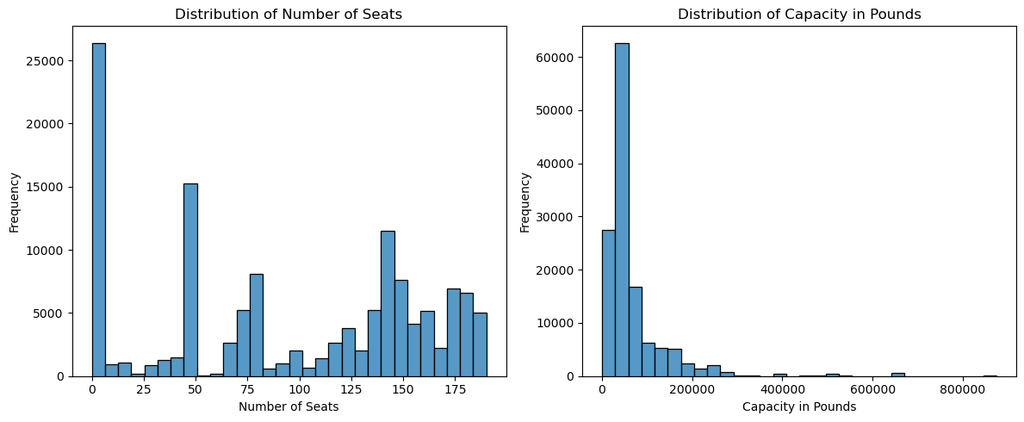

```python
# Histogram Plots
fig, axes = plt.subplots(1, 2, figsize=(12, 5))
sns.histplot(inventory['NUMBER_OF_SEATS'], bins = 30, ax = axes[0])
axes[0].set_title('Distribution of Number of Seats')
axes[0].set_xlabel('Number of Seats')
axes[0].set_ylabel('Frequency')

sns.histplot(inventory['CAPACITY_IN_POUNDS'], bins = 30, ax = axes[1])
axes[1].set_title('Distribution of Capacity in Pounds')
axes[1].set_xlabel('Capacity in Pounds')
axes[1].set_ylabel('Frequency')

plt.tight_layout()
plt.show()
```

Number of seats has a skewness of -0.17, which highlights it is almost a symmetric distribution that has a slight skew to the left. However, the histogram paints a clearer picture - there is a a large spike at aircrafts having 0 flights, which represents the cargo type of aircrafts which do not host passengers so need 0 seats. Additionally, there is a multimodal distribution in the number of seats, with peaks at 50, 75, 140 and 175 seats. This reflects that aircrafts have different configurations based on how much capacity they are meant to handle - and there are very few custom aircrafts that have a specific number of seats away from these larger spikes.

On the other hand, the capacity in pounds of an aircraft has a skewness of 4.28 which highlights that the distribution is highly skewed towards the right. This is evident in the histogram where we observe that a majority of aircrafts lie in the 0-100000 lbs range. Only a small proportion of aircrafts have capacity greater than that, making analysis difficult if the assumption of normality in the dataset is required. These results of high skewness indicate that a log transformation could be applied to this column to make further analysis more precise and relevant.

##### Box-Cox Transformation

```python
def boxcox_transformation(df):
    df = df.copy()
    # To apply the boxcox transformation, the data needs to be wholly positive. Thus, 1 is added to the columns to ensure all values are positive and non-zero.
    df['NUMBER_OF_SEATS_BOXCOX'] = df['NUMBER_OF_SEATS'] + 1
    df['CAPACITY_IN_POUNDS_BOXCOX'] = df['CAPACITY_IN_POUNDS'] + 1
    df['NUMBER_OF_SEATS_BOXCOX'] = scipy.stats.boxcox(df['NUMBER_OF_SEATS_BOXCOX'])[0]
    df['CAPACITY_IN_POUNDS_BOXCOX'] = scipy.stats.boxcox(df['CAPACITY_IN_POUNDS_BOXCOX'])[0]
    return df

inventory = boxcox_transformation(inventory)
```

```python
seat_skew_post = inventory['NUMBER_OF_SEATS_BOXCOX'].skew()
print(f'Skewness of Number of Seats: {seat_skew_post:.2f}')
capacity_skew_post = inventory['CAPACITY_IN_POUNDS_BOXCOX'].skew()
print(f'Skewness of Capacity in Pounds: {capacity_skew_post:.2f}')
```

```
Skewness of Number of Seats: -0.63
Skewness of Capacity in Pounds: 0.25
```

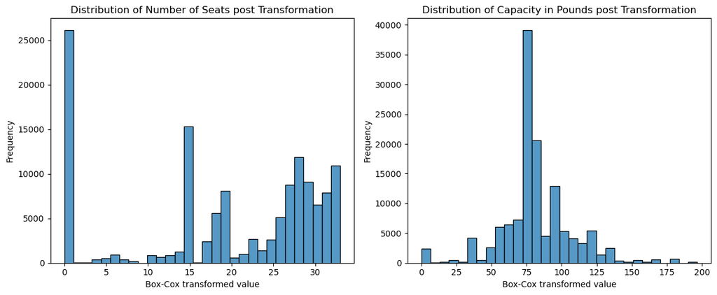

```python
# Histogram Plots
fig, axes = plt.subplots(1, 2, figsize=(12, 5))
sns.histplot(inventory['NUMBER_OF_SEATS_BOXCOX'], bins = 30, ax = axes[0])
axes[0].set_title('Distribution of Number of Seats post Transformation')
axes[0].set_xlabel('Box-Cox transformed value')
axes[0].set_ylabel('Frequency')

sns.histplot(inventory['CAPACITY_IN_POUNDS_BOXCOX'], bins = 30, ax = axes[1])
axes[1].set_title('Distribution of Capacity in Pounds post Transformation')
axes[1].set_xlabel('Box-Cox transformed value')
axes[1].set_ylabel('Frequency')

plt.tight_layout()
plt.show()
```

##### Analysis of Transformed Data Distributions

On the other, for the Capacity in Pounds, the Box-Cox transformation performs quite well. The initial heavy right skew of the data has reduced significantly to 0.25, and the sharp spike occuring at lower values has been flattened out, with the long-tailing extending to the right being eliminated. Post the transformation, the data is significantly more symmetrically distributed and has a bell-shaped curve arounded a central transformed value of about 75. This makes it appropriate for analysis using methods that assume normality in the data distribution.

#### Task 5

```python
# Creating a "Size" column based on quartile ranges for Number of Seats
def size_col_creation(df):
    df = df.copy()
    q25 = df['NUMBER_OF_SEATS'].quantile(0.25)
    q50 = df['NUMBER_OF_SEATS'].quantile(0.50)
    q75 = df['NUMBER_OF_SEATS'].quantile(0.75)
    df['SIZE'] = pd.cut(
        df['NUMBER_OF_SEATS'], bins = [-np.inf, q25, q50, q75, np.inf],
        labels = ['SMALL', 'MEDIUM', 'LARGE', 'XLARGE']
    )
    return df

inventory = size_col_creation(inventory)
```

```
OPERATING_STATUS       N       Y
SIZE
SMALL             0.0560  0.9440
MEDIUM            0.0413  0.9587
LARGE             0.0414  0.9586
XLARGE            0.0245  0.9755
```

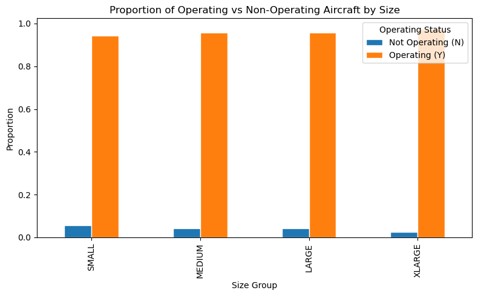

```python
# Proportion Table and Plot for Operating Status
prop_table_operating = (inventory.groupby('SIZE')['OPERATING_STATUS']
                        .value_counts(normalize = True)
                        .unstack('OPERATING_STATUS')
                        .round(4))

print(prop_table_operating)

# Plot
prop_table_operating.plot(kind = 'bar', figsize = (8,5), edgecolor = 'white')
plt.title('Proportion of Operating vs Non-Operating Aircraft by Size')
plt.xlabel('Size Group')
plt.ylabel('Proportion')
plt.legend(title = 'Operating Status', labels = ['Not Operating (N)', 'Operating (Y)'])
plt.tight_layout()
plt.show()
```

```
AIRCRAFT_STATUS       A       B       L       O
SIZE
SMALL            0.0431  0.3851  0.0001  0.5717
MEDIUM           0.0261  0.4148  0.0001  0.5590
LARGE            0.1187  0.2800  0.0013  0.5999
XLARGE           0.0808  0.2411  0.0023  0.6758
```

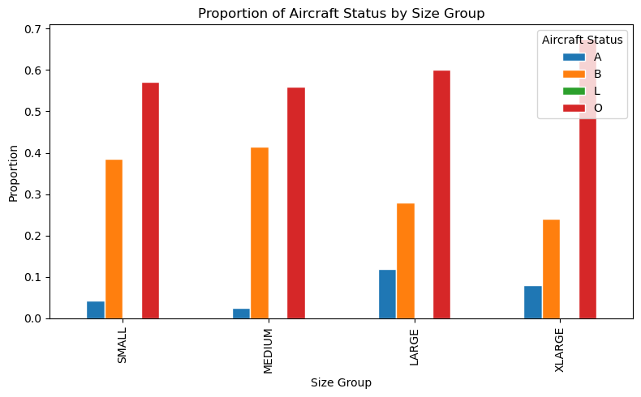

```python
# Proportion Table and Plot for Aircraft Status
prop_table_aircraft = (inventory.groupby('SIZE')['AIRCRAFT_STATUS']
                        .value_counts(normalize = True)
                        .unstack('AIRCRAFT_STATUS')
                        .round(4))

print(prop_table_aircraft)

# Plot
prop_table_aircraft.plot(kind = 'bar', figsize = (8,5), edgecolor = 'white')
plt.title('Proportion of Aircraft Status by Size Group')
plt.xlabel('Size Group')
plt.ylabel('Proportion')
plt.legend(title = 'Aircraft Status')
plt.tight_layout()
plt.show()
```

##### Analysis of Findings

Looking at the operating status of aircrafts across the size-based grouping, the vast majority of aircrafts in each size group are in active operating status. A slight trend of larger aircrafts having higher rates of operation can be observed, but this is marginal - ranging from 94.4% for SMALL to 97.6% for XLARGE. These differences are small and may not have much significance in a practical sense. The main takeaway from the operating status is that most of the aircrafts described in the dataset are in active operation, regardless of their size.

On the other, whilst looking at aircraft status, a dominant category 'O' (operating) emerges. This ranges from 57.2% for SMALL to 67.6% for XLARGE, continuing to reinforce the earlier notion that the larger an aircraft is, the more heavy its active utilization. On the other hand, the opposite trend can be observed in category 'B' (stored or inactive) can be observed. It actually demonstrates a decline from 38.5% for the SMALL aircraft to 24.1% for the XLARGE, indicating that smaller planes have a higher likelihood of being kept in storage. In Category 'A' (adminstrative or special status), the proportion of LARGE and XLARGE aircrafts is significantly higher when compared to SMALL and MEDIUM. This indicates that larger aircrafts are more likely to undergo maintainance, transitions in lease and experience adminstrative holds. Across all the size groups, Category L is negligible at less than 0.3% representation.

#### Task 6

```python
# Preparing dataset for modelling
features_for_reg = ['YEAR', 'MANUFACTURE_YEAR', 'MANUFACTURER', 'MODEL', 'AIRCRAFT_STATUS', 'OPERATING_STATUS']
target_seats = 'NUMBER_OF_SEATS'
target_capacity = 'CAPACITY_IN_POUNDS'

inventory_model = inventory[features_for_reg + [target_seats, target_capacity]].copy()
inventory_model = inventory_model.dropna()
categorical_vars = ['MANUFACTURER', 'MODEL', 'AIRCRAFT_STATUS', 'OPERATING_STATUS']
for var in categorical_vars:
    inventory_model[var] = LabelEncoder().fit_transform(inventory_model[var].astype(str))


inventory_model = inventory_model.dropna()

# 80-20 Train Test Split
train, test = train_test_split(inventory_model, test_size = 0.2, random_state = 42)
X_train = train[features_for_reg]
X_test  = test[features_for_reg]
y_train_seats    = train[target_seats]
y_test_seats     = test[target_seats]
y_train_capacity = train[target_capacity]
y_test_capacity  = test[target_capacity]
```

```python
# RMSE Calculator
def rmse_calc(y_true, y_pred):
    return np.sqrt(mean_squared_error(y_true, y_pred))
```

```python
# Multivariate Regression for Number of Seats
seats_lr = LinearRegression()
seats_lr.fit(X_train, y_train_seats)

print('Multivariate Regression for Number of Seats')
print(f'Train RMSE: {rmse_calc(y_train_seats, seats_lr.predict(X_train)):.4f}')
print(f'Test RMSE: {rmse_calc(y_test_seats, seats_lr.predict(X_test)):.4f}')
```

```
Multivariate Regression for Number of Seats
Train RMSE: 57.4658
Test RMSE: 57.8696
```

```python
# Multivariate Regression for Capacity in Pounds
capacity_lr = LinearRegression()
capacity_lr.fit(X_train, y_train_capacity)

print('Multivariate Regression for Capacity in Pounds')
print(f'Train RMSE: {rmse_calc(y_train_capacity, capacity_lr.predict(X_train)):.4f}')
print(f'Test RMSE: {rmse_calc(y_test_capacity, capacity_lr.predict(X_test)):.4f}')
```

```
Multivariate Regression for Capacity in Pounds
Train RMSE: 81886.6092
Test RMSE: 81693.2301
```

```python
# Random Forest for Number of Seats
seats_rf = RandomForestRegressor(n_estimators = 100, random_state = 42)
seats_rf.fit(X_train, y_train_seats)

print('Random Forest Model for Number of Seats')
print(f'Train RMSE: {rmse_calc(y_train_seats, seats_rf.predict(X_train)):.4f}')
print(f'Test RMSE: {rmse_calc(y_test_seats, seats_rf.predict(X_test)):.4f}')
```

```
Random Forest Model for Number of Seats
Train RMSE: 13.1275
Test RMSE: 16.1397
```

```python
# Random Forest for Capacity in Pounds
capacity_rf = RandomForestRegressor(n_estimators = 100, random_state = 42)
capacity_rf.fit(X_train, y_train_capacity)

print('Random Forest Model for Capacity in Pounds')
print(f'Train RMSE: {rmse_calc(y_train_capacity, capacity_rf.predict(X_train)):.4f}')
print(f'Test RMSE: {rmse_calc(y_test_capacity, capacity_rf.predict(X_test)):.4f}')
```

```
Random Forest Model for Capacity in Pounds
Train RMSE: 9800.3758
Test RMSE: 13354.3643
```

The use of a random forest model significantly overshadows linear regression in performance for both the target variables - number of seats and capacity in pounds. In the case of number of seats, the test RMSE reduces by ~72% from 57.9 to 16.1. This improvement is a lot more dramatic in the case of capacity in pounds. It drops from 81693 to 13354, which represents a 84% reduction in the modelling error. Given that both the number of seats and capacity of aircraft are highly determined by the specific model of aircraft, these results makes sense. This is because this relationship is a highly non-linear categorical one that the linear regression models cannot capture well. However, the use of tree-based splits in the random forest models allow for this to be handled a lot better, creating more precise models.

The linear regression cases show minimal overfitting for both targets, with almost no difference between the test and train RMSE. However, this gap is a lot more noticeable for the random forest models (train RMSE 13.1 vs test RMSE 16.1 for seats, 9800 vs 13354 for capacity). This indicates that there is a definite degree of overfitting as is typical of random forest models given that they memorize training data. However, this is not a severe gap and random forest models remain to be the superior models for both prediction-related tasks.